# **Analyse de données d’écologie forestière dans le bois de Montrond**

# 4 Analyse en composantes principales sur la biomasse

A présent, il peut être intéressant de se pencher sur la biomasse et non sur le nombre d’individus. Pour cela, on analyse la grandeur suivante:s biomasse/placette/espèce. On effectue pour cela une ACP. La biomasse est représentée par la surface terrière des arbres, calculée à partir de leur circonférence.

```r
diversite_s<-read.csv("Diversite_Surface.csv")
elim=c("Placette","Sous_placette","Topo","Exposition")
diversite_s2=diversite_s[,!names(diversite_s)%in%elim]
acp<-dudi.pca(diversite_s2, scannf=FALSE, nf=3)
acp
```

```
## Duality diagramm
## class: pca dudi
## $call: dudi.pca(df = diversite_s2, scannf = FALSE, nf = 3)
##
## $nf: 3 axis-components saved
## $rank: 17
## eigen values: 2.567 2.051 2.021 1.677 1.472 ...
##   vector length mode    content
## 1 $cw    20     numeric column weights
## 2 $lw    30     numeric row weights
## 3 $eig   17     numeric eigen values
##
##   data.frame nrow ncol content
## 1 $tab       30   20   modified array
## 2 $li        30   3    row coordinates
## 3 $l1        30   3    row normed scores
## 4 $co        20   3    column coordinates
## 5 $c1        20   3    column normed scores
## other elements: cent norm
```

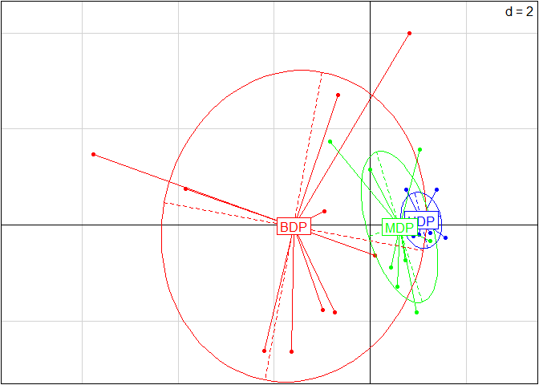

```r
topo<-as.factor(diversite_s$Topo)
exposition<-as.factor(diversite_s$Exposition)
gcol <- c("red", "blue","green")
gcol1<-c("black","orange")
s.class(dfxy = acp$li, fac = topo, col = gcol, xax = 1, yax = 2)
```

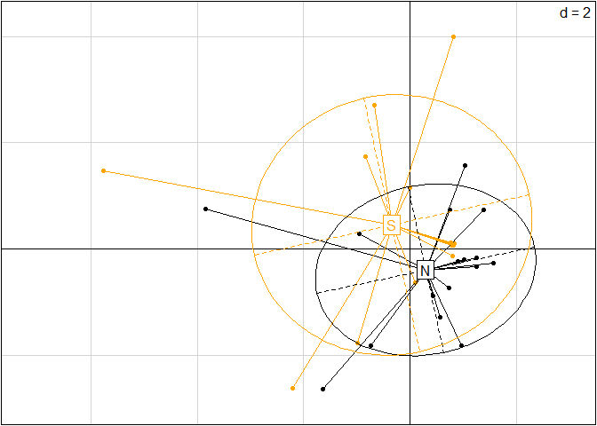

```r
s.class(dfxy = acp$li, fac = exposition, col = gcol1, xax = 1, yax = 2)
```

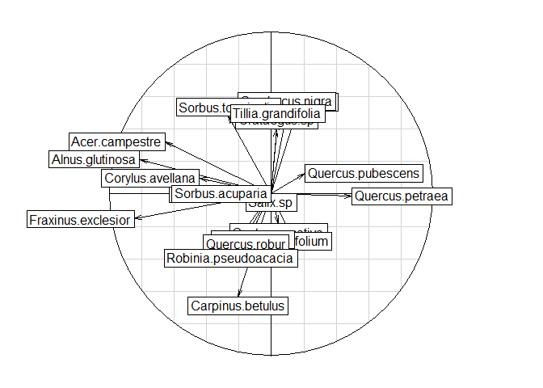

```r
s.corcircle(acp$co, xax = 1, yax = 2)
```

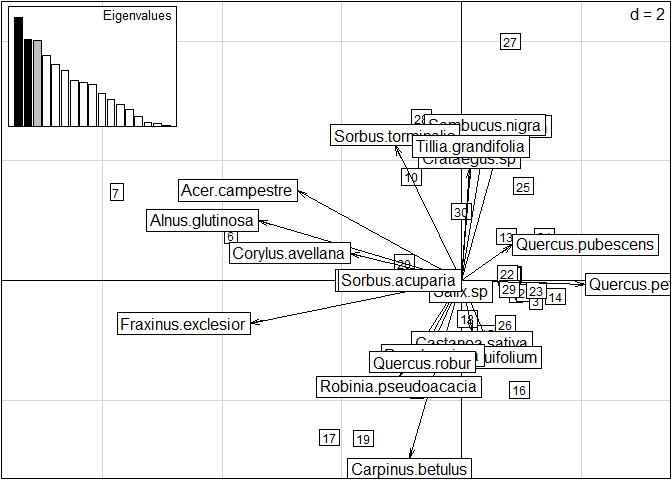

```r
scatter(acp)
```

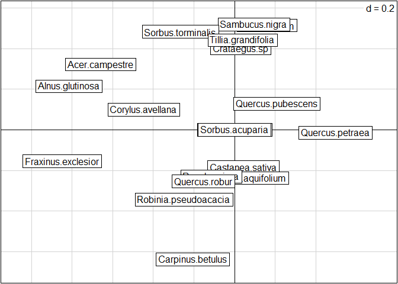

```r
s.label(acp$co, xax=1, yax=2)
```

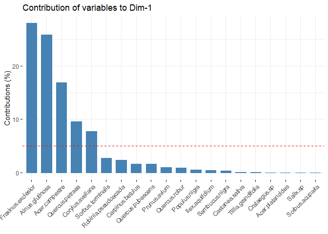

```r
fviz_contrib(acp, choice="var")
```

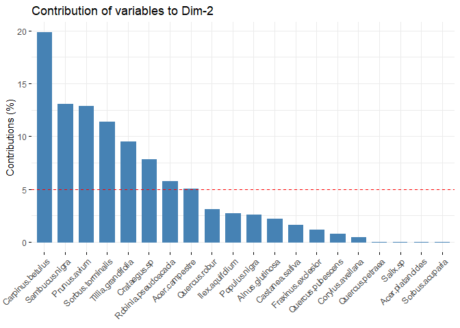

```r
fviz_contrib(acp, choice="var", axes=2)
```

Cette fois, c’est l’axe 1 qui sépare le bas de pente du milieu de pente et du haut de pente (qui sont tout de même moins ségrégés que dans l’AFC). L’axe 2 explique l’effet de l’exposition, qui est aussi moins marqué que dans l’AFC.

On observe cette fois un effet de la taille : les frênes et les aulnes, qui avaient généralement une circonférence élevée, ont une contribution plus importante à l’axe 1.

Comme pour l’AFC, quantifions cela via une BCA.

```r
bca3<-bca(x=acp, fac=topo, scannf=FALSE, nf=2)
bca4<-bca(x=acp, fac=exposition, scannf=FALSE, nf=2)
bca3
```

```
## Between analysis
## call: bca.dudi(x = acp, fac = topo, scannf = FALSE, nf = 2)
## class: between dudi
##
## $nf (axis saved) : 2
## $rank:  2
## $ratio:  0.1278925
##
## eigen values: 1.821 0.3527
##
##   vector length mode    content
## 1 $eig   2      numeric eigen values
## 2 $lw    3      numeric group weigths
## 3 $cw    20     numeric col weigths
##
##   data.frame nrow ncol content
## 1 $tab       3    20   array class-variables
## 2 $li        3    2    class coordinates
## 3 $l1        3    2    class normed scores
## 4 $co        20   2    column coordinates
## 5 $c1        20   2    column normed scores
## 6 $ls        30   2    row coordinates
## 7 $as        3    2    inertia axis onto between axis
```

```r
bca4
```

```
## Between analysis
## call: bca.dudi(x = acp, fac = exposition, scannf = FALSE, nf = 2)
## class: between dudi
##
## $nf (axis saved) : 1
## $rank:  1
## $ratio:  0.07320598
##
## eigen values: 1.245
##
##   vector length mode    content
## 1 $eig   1      numeric eigen values
## 2 $lw    2      numeric group weigths
## 3 $cw    20     numeric col weigths
##
##   data.frame nrow ncol content
## 1 $tab       2    20   array class-variables
## 2 $li        2    1    class coordinates
## 3 $l1        2    1    class normed scores
## 4 $co        20   1    column coordinates
## 5 $c1        20   1    column normed scores
## 6 $ls        30   1    row coordinates
## 7 $as        3    1    inertia axis onto between axis
```

Dans ce cas, la topographie explique 12% de la variance, alors que l’exposition explique 7%.

On peut également réaliser une analyse discrimante.

```r
acp2<-dudi.coa(df=diversite_s2, scannf=FALSE, nf=ncol(diversite_s2)-1)
dis<-discrimin(dudi=acp2, fac=as.factor(diversite_s$Topo), scannf=FALSE)
```

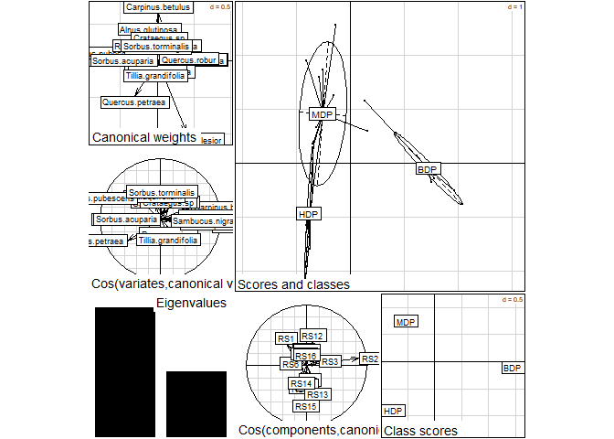

```r
plot(dis)
```